# CARPS Reproducibility Report

# Report Details

```r
articleID <- 2-11-2015  # insert the article ID code here e.g., "10-3-2015_PS"
reportType <- 'final'  # specify whether this is the 'pilot' report or 'final' report
pilotNames <- "Pérez, Greses" # insert the pilot's name here e.g., "Tom Hardwicke".  If there are multiple cpilots enter both names in a character string e.g., "Tom Hardwicke, Bob Dylan"
copilotNames <- "Cachia, Julie Youko Anne" # # insert the co-pilot's name here e.g., "Michael Frank". If there are multiple co-pilots enter both names in a character string e.g., "Tom Hardwicke, Bob Dylan"
pilotTTC <- 1200 # insert the pilot's estimated time to complete (in minutes, fine to approximate) e.g., 120
copilotTTC <- 180 # insert the co-pilot's estimated time to complete (in minutes, fine to approximate) e.g., 120
pilotStartDate <- as.Date("11/02/18",format= "%m/%d/%y") # insert the pilot's start date in US format e.g., as.Date("01/25/18", format = "%m/%d/%y")
copilotStartDate <- as.Date("11/08/18",format= "%m/%d/%y") # insert the co-pilot's start date in US format e.g., as.Date("01/25/18", format = "%m/%d/%y")
completionDate <- as.Date("11/08/18",format= "%m/%d/%y") # copilot insert the date of final report completion (after any necessary rounds of author assistance) in US format e.g., as.Date("01/25/18", format = "%m/%d/%y")
```

#### Methods summary:

The authors assembled an experiment where 5-years-olds learned a set of pictures with pairs of objects associated to a cartoon character to investigate the effects of consolidation on children’s memory by introducing a 1 min delay between learning and testing in the no-delay experiment. Three learning phases, 1 and 3 presented identical contingencies and 2 different contingencies. Darby & Sloutsky (2015) also evaluated the results for interference and savings following a 2 (phase: 1 vs. 3) × 2 (pair type: overlapping vs. unique) analysis of variance (ANOVA).

#### Target outcomes:

For this article you should focus on the findings reported in the results section for Experiment 1.

Specifically, you should attempt to reproduce all descriptive and inferential analyses reported in the text below and associated tables/figures:

> No-delay condition. Results in the no-delay condition pointed to substantial retroactive interference, which was confirmed by a 2 (phase: 1 vs. 3) × 2 (pair type: overlapping vs. unique) repeated measures analysis of variance (ANOVA), which revealed a significant interaction, F(1, 24) = 13.04, p = .001, ηp 2 = .35. Planned comparisons indicated that accuracy significantly decreased for overlapping pairs, t(24) = 6.82, p < .001, Cohen’s d = 1.39, but not for unique pairs, p = .46. To determine the extent of retroactive interference effects on children’s memory, we also measured savings effects. Results pointed to savings for unique but not for overlapping pairs: A 2 (phase: 1 vs. 3) × 2 (pair type: overlapping vs. unique) repeated measures ANOVA revealed a significant interaction, F(1, 22) = 12.02, p = .002, ηp 2 = .33, with savings transpiring for unique pairs, t(24) = 5.82, p < .001, d = 1.19, but not for overlapping pairs, p = .56. Substantial retroactive interference coupled with no savings for overlapping pairs points to catastrophic- like levels of retroactive interference, which replicates our previous findings (Darby & Sloutsky, 2015).

We also attempted to reproduce Figure 2 Experiment 1 No Delay only.

# Step 1: Load packages and prepare report object

```r
# load packages
library(tidyverse) # for data munging
library(knitr) # for kable table formating
library(haven) # import and export 'SPSS', 'Stata' and 'SAS' Files
library(readxl) # import excel files
library(CARPSreports) # custom report functions

library('dplyr')      # for data manipulation
library('tidyr')      # for reshaping data

library('ggplot2')    # plotting data
library('scales')     # for scale_y_continuous(label = percent)
library('ggthemes')   # for scale_fill_few('medium')
knitr::opts_chunk$set(comment = NA)
options(ztable.type = 'html')
#install.packages("ez") #Uncomment and run this line if you do not have "ez" installed
library(ez)
```

```r
# Prepare report object. This will be updated automatically by the reproCheck function each time values are compared
reportObject <- data.frame(dummyRow = TRUE, reportedValue = NA, obtainedValue = NA, valueType = NA, percentageError = NA, comparisonOutcome = NA, eyeballCheck = NA)
```

# Step 2: Load data

```r
Data <- read_excel("data/All Data for Repository-Final_gp.xlsx")
str(Data)
```

```
Classes 'tbl_df', 'tbl' and 'data.frame':   2370 obs. of  6 variables:
 $ experiment: chr  "Experiment 1 No Delay" "Experiment 1 No Delay" "Experiment 1 No Delay" "Experiment 1 No Delay" ...
 $ subject   : num  3049 3049 3049 3049 3049 ...
 $ phase     : num  1 1 1 1 1 1 1 1 1 1 ...
 $ block     : num  1 1 2 2 3 3 4 4 5 5 ...
 $ pair type : chr  "overlapping" "unique" "overlapping" "unique" ...
 $ accuracy  : num  1 0.5 1 0.75 1 1 1 1 1 1 ...
```

```r
head(Data)
```

```
# A tibble: 6 x 6
  experiment            subject phase block `pair type` accuracy
  <chr>                   <dbl> <dbl> <dbl> <chr>          <dbl>
1 Experiment 1 No Delay    3049     1     1 overlapping     1
2 Experiment 1 No Delay    3049     1     1 unique          0.5
3 Experiment 1 No Delay    3049     1     2 overlapping     1
4 Experiment 1 No Delay    3049     1     2 unique          0.75
5 Experiment 1 No Delay    3049     1     3 overlapping     1
6 Experiment 1 No Delay    3049     1     3 unique          1
```

```r
#Take a look at the data
summary(Data)
```

```
  experiment           subject           phase       block
 Length:2370        Min.   :  3007   Min.   :1   Min.   :1
 Class :character   1st Qu.:  3034   1st Qu.:1   1st Qu.:2
 Mode  :character   Median :  3059   Median :2   Median :3
                    Mean   : 22472   Mean   :2   Mean   :3
                    3rd Qu.:  3136   3rd Qu.:3   3rd Qu.:4
                    Max.   :900010   Max.   :3   Max.   :5
  pair type            accuracy
 Length:2370        Min.   :0.0000
 Class :character   1st Qu.:0.7500
 Mode  :character   Median :1.0000
                    Mean   :0.8402
                    3rd Qu.:1.0000
                    Max.   :1.0000
```

# Step 3: Tidy data

```r
#The data is already tidy
```

# Step 4: Run analysis

## Pre-processing

```r
# get the data clean for analysis
d <- Data %>%
  rename(pair_type = `pair type`)
head(d)
```

```
# A tibble: 6 x 6
  experiment            subject phase block pair_type   accuracy
  <chr>                   <dbl> <dbl> <dbl> <chr>          <dbl>
1 Experiment 1 No Delay    3049     1     1 overlapping     1
2 Experiment 1 No Delay    3049     1     1 unique          0.5
3 Experiment 1 No Delay    3049     1     2 overlapping     1
4 Experiment 1 No Delay    3049     1     2 unique          0.75
5 Experiment 1 No Delay    3049     1     3 overlapping     1
6 Experiment 1 No Delay    3049     1     3 unique          1
```

## Descriptive statistics

```r
#Replication of Table 1 on page 1941 of the article

# summarize by the right grouping factors
d_summary <- d %>%
  filter(experiment == "Experiment 1 No Delay") %>%
  group_by(experiment, phase, pair_type, block) %>%
  summarise(mean = mean(accuracy),
            sd = sd(accuracy))

# output step - format into a wide table
d_summary %>%
  select(-sd) %>%
  spread(block, mean)
```

```
# A tibble: 6 x 8
# Groups:   experiment, phase, pair_type [6]
  experiment            phase pair_type     `1`   `2`   `3`   `4`   `5`
  <chr>                 <dbl> <chr>       <dbl> <dbl> <dbl> <dbl> <dbl>
1 Experiment 1 No Delay     1 overlapping  0.6   0.91  0.91  0.92  0.93
2 Experiment 1 No Delay     1 unique       0.56  0.88  0.88  0.93  0.92
3 Experiment 1 No Delay     2 overlapping  0.48  0.78  0.91  0.88  0.91
4 Experiment 1 No Delay     2 unique       0.7   0.93  0.93  0.97  0.97
5 Experiment 1 No Delay     3 overlapping  0.64  0.85  0.89  0.93  0.95
6 Experiment 1 No Delay     3 unique       0.88  0.93  0.96  0.92  0.94
```

```r
d_summary %>%
  select(-mean) %>%
  spread(block, sd)
```

```
# A tibble: 6 x 8
# Groups:   experiment, phase, pair_type [6]
  experiment            phase pair_type     `1`   `2`    `3`   `4`    `5`
  <chr>                 <dbl> <chr>       <dbl> <dbl>  <dbl> <dbl>  <dbl>
1 Experiment 1 No Delay     1 overlapping 0.25  0.142 0.142  0.173 0.153
2 Experiment 1 No Delay     1 unique      0.181 0.193 0.163  0.135 0.157
3 Experiment 1 No Delay     2 overlapping 0.216 0.263 0.122  0.163 0.159
4 Experiment 1 No Delay     2 unique      0.217 0.135 0.135  0.110 0.0829
5 Experiment 1 No Delay     3 overlapping 0.240 0.204 0.192  0.135 0.125
6 Experiment 1 No Delay     3 unique      0.218 0.153 0.0935 0.139 0.109
```

```r
# Initial calculations for savings
d_savings = d %>%
filter(experiment == "Experiment 1 No Delay") %>%
  filter((phase %in% c(1, 3)) & block == 1) %>%
  spread(phase, accuracy) %>%
  mutate(savings=`3`-`1`)
head(d_savings)
```

```
# A tibble: 6 x 7
  experiment            subject block pair_type     `1`   `3` savings
  <chr>                   <dbl> <dbl> <chr>       <dbl> <dbl>   <dbl>
1 Experiment 1 No Delay    3049     1 overlapping  1     0.75   -0.25
2 Experiment 1 No Delay    3049     1 unique       0.5   0.75    0.25
3 Experiment 1 No Delay    3052     1 overlapping  0.75  0.5    -0.25
4 Experiment 1 No Delay    3052     1 unique       0.5   1       0.5
5 Experiment 1 No Delay    3053     1 overlapping  0.75  0.5    -0.25
6 Experiment 1 No Delay    3053     1 unique       0.75  1       0.25
```

```r
# Spread savings by pair type
d_savings_split <- d_savings%>%
  select(-block)%>%
    select(-`1`)%>%
  select(-`3`)%>%
  spread(pair_type, savings)
head(d_savings_split)
```

```
# A tibble: 6 x 4
  experiment            subject overlapping unique
  <chr>                   <dbl>       <dbl>  <dbl>
1 Experiment 1 No Delay    3049       -0.25   0.25
2 Experiment 1 No Delay    3052       -0.25   0.5
3 Experiment 1 No Delay    3053       -0.25   0.25
4 Experiment 1 No Delay    3056        0.25   0
5 Experiment 1 No Delay    3066        0      0.5
6 Experiment 1 No Delay    3068       -0.75  -0.25
```

```r
# Initial calculations for retroactive interference
d_pre_ri = d %>%
  filter(experiment == "Experiment 1 No Delay") %>%
  filter((phase == 1 & block == 5) | (phase == 3 & block ==1 ))%>%
  select(-block)%>%
  spread(phase, accuracy)%>%
  mutate(pre_ri =`1` - `3`) #This is Phase 1 Block 5 and Phase 3 Block 1 separately for overlapping and unique pairs as indicated on p.1939 from the article
  head(d_pre_ri)
```

```
# A tibble: 6 x 6
  experiment            subject pair_type     `1`   `3` pre_ri
  <chr>                   <dbl> <chr>       <dbl> <dbl>  <dbl>
1 Experiment 1 No Delay    3049 overlapping  1     0.75   0.25
2 Experiment 1 No Delay    3049 unique       1     0.75   0.25
3 Experiment 1 No Delay    3052 overlapping  1     0.5    0.5
4 Experiment 1 No Delay    3052 unique       0.75  1     -0.25
5 Experiment 1 No Delay    3053 overlapping  1     0.5    0.5
6 Experiment 1 No Delay    3053 unique       1     1      0
```

```r
# Calculation of retroactive interference (named as "rio" in this code)
# I attempted to create figure 2 on page 1941 as requested for this project, but I was unable to replicate it and given the fact that I have spend a considerable amount of time in this project, I decided to move on to the next problem set. If someone gets to do it in the near future, I would love to have access to the complete code (greses@stanford.edu)

d_ri <- d_pre_ri %>%
  select(-`1`,-`3`)%>%
  spread(pair_type, pre_ri)%>%
  mutate(rio = overlapping-unique)%>%  #This is determining the difference between results for each pair type as indicated on p.1939 from the article
  mutate(mean_rio=mean(rio))
head(d_ri)
```

```
# A tibble: 6 x 6
  experiment            subject overlapping unique   rio mean_rio
  <chr>                   <dbl>       <dbl>  <dbl> <dbl>    <dbl>
1 Experiment 1 No Delay    3049        0.25   0.25  0        0.25
2 Experiment 1 No Delay    3052        0.5   -0.25  0.75     0.25
3 Experiment 1 No Delay    3053        0.5    0     0.5      0.25
4 Experiment 1 No Delay    3056        0      0     0        0.25
5 Experiment 1 No Delay    3066        0.25   0     0.25     0.25
6 Experiment 1 No Delay    3068        0.25   0.5  -0.25     0.25
```

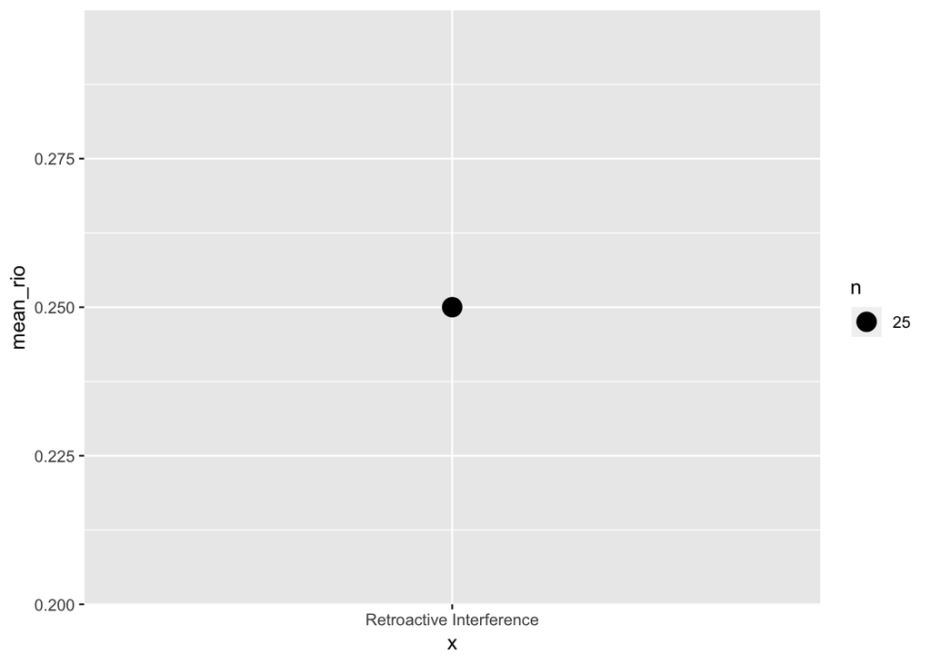

```r
ggplot(d_ri, aes(x = "Retroactive Interference", y = mean_rio)) +
         geom_count() # I did not know how to turn these values into rows, so I could create teh graph as shown on page p. 1939 of the study.
```

```r
# Calculations to take the data apart to graph figure 1 and 2 of the paper. I was unable to bring together the savings data and retroactive inference, so I could not graph figure 1.

total <- merge(d_savings_split, d_ri, by="subject")%>%
  select(-`unique.y`,-`overlapping.y`,-`experiment.y`)%>%
  mutate(mean_overlapping=mean(`overlapping.x`))%>%
  mutate(mean_unique=mean(`unique.x`))
head(total)
```

```
  subject          experiment.x overlapping.x unique.x   rio mean_rio
1    3049 Experiment 1 No Delay         -0.25     0.25  0.00     0.25
2    3052 Experiment 1 No Delay         -0.25     0.50  0.75     0.25
3    3053 Experiment 1 No Delay         -0.25     0.25  0.50     0.25
4    3056 Experiment 1 No Delay          0.25     0.00  0.00     0.25
5    3066 Experiment 1 No Delay          0.00     0.50  0.25     0.25
6    3068 Experiment 1 No Delay         -0.75    -0.25 -0.25     0.25
  mean_overlapping mean_unique
1             0.04        0.32
2             0.04        0.32
3             0.04        0.32
4             0.04        0.32
5             0.04        0.32
6             0.04        0.32
```

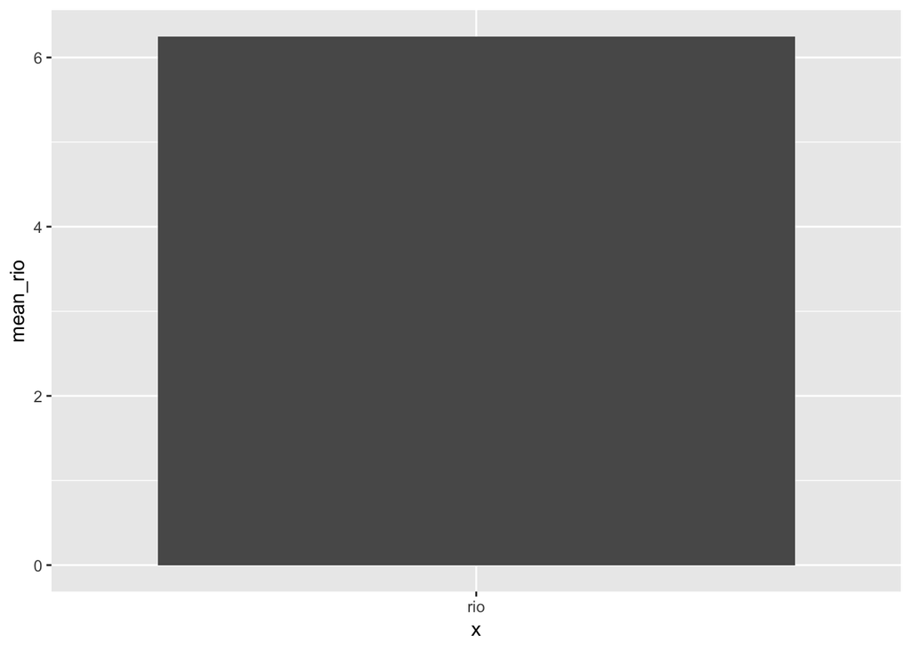

```r
# As described in the text above, I was unable to replicate the graphs 1 and 2

ggplot(total, aes(x = "rio", y = mean_rio), aes(x2="unique", y2=mean_unique)) +
  geom_col()
```

## Inferential statistics

> substantial retroactive interference, confirmed by a 2 (phase: 1 vs. 3) × 2 (pair type: overlapping vs. unique) repeated measures analysis of variance (ANOVA), which revealed a significant interaction, F(1, 24) = 13.04, p = .001, ηp 2 = .35.

```r
d_anova <-d %>%
  filter(experiment == "Experiment 1 No Delay") %>%
  filter((phase == 1 & block == 5) | (phase == 3 & block ==1 ))
model_anova <-aov(accuracy ~ phase + pair_type, data=d_anova)
summary.aov(model_anova) #I have followed the steps indicated in the study, but the description of the analysis in the paper is very ambiguous. I consulted with the TA's and they said that this paper is a good example of "what not to do when describing the analysis"
```

```
            Df Sum Sq Mean Sq F value   Pr(>F)
phase        1  0.681  0.6806  16.219 0.000112 ***
pair_type    1  0.331  0.3306   7.879 0.006047 **
Residuals   97  4.071  0.0420
---
Signif. codes:  0 '***' 0.001 '**' 0.01 '*' 0.05 '.' 0.1 ' ' 1
```

```r
##Planned comparisons indicated that accuracy significantly decreased for overlapping pairs, t(24) = 6.82, p < .001, Cohen’s d = 1.39

t <- t.test(d_ri$overlapping)
head(t)
```

```
$statistic
       t
6.819598

$parameter
df
24

$p.value
[1] 4.711565e-07

$conf.int
[1] 0.2022337 0.3777663
attr(,"conf.level")
[1] 0.95

$estimate
mean of x
     0.29

$null.value
mean
   0
```

```r
# accuracy did not decrease for unique pairs, p = .46.
t.ri.u <- t.test(d_ri$unique)
head(t.ri.u)
```

```
$statistic
        t
0.7492686

$parameter
df
24

$p.value
[1] 0.4609768

$conf.int
[1] -0.07018203  0.15018203
attr(,"conf.level")
[1] 0.95

$estimate
mean of x
     0.04

$null.value
mean
   0
```

#### To determine the extent of retroactive interference effects on children’s memory, we also measured savings effects. Results pointed to savings for unique but not for overlapping pairs: A 2 (phase: 1 vs. 3) × 2 (pair type: overlapping vs. unique) repeated measures ANOVA revealed a significant interaction, F(1, 22) = 12.02, p = .002, ηp 2 = .33

```r
das <- d%>%
  filter(experiment=="Experiment 1 No Delay" & block==1)%>%
  filter((phase==1) |(phase==3))
model_das <-aov(accuracy~ phase + pair_type, data = das)
summary.aov(model_das) # I have followed the steps indicated in the study, but the description of the analysis in the paper is very ambiguous. I consulted with the TA's and they said that this paper is a good example of "what not to do when describing the analysis"
```

```
            Df Sum Sq Mean Sq F value   Pr(>F)
phase        1   0.81  0.8100  14.825 0.000212 ***
pair_type    1   0.25  0.2500   4.575 0.034943 *
Residuals   97   5.30  0.0546
---
Signif. codes:  0 '***' 0.001 '**' 0.01 '*' 0.05 '.' 0.1 ' ' 1
```

```r
# savings transpiring for unique pairs, t(24) = 5.82, p < .001, d = 1.19, but not for overlapping pairs, p = .56.

t.savings <- t.test(d_savings_split$unique)
head(t.savings)
```

```
$statistic
       t
5.818182

$parameter
df
24

$p.value
[1] 5.336859e-06

$conf.int
[1] 0.2064856 0.4335144
attr(,"conf.level")
[1] 0.95

$estimate
mean of x
     0.32

$null.value
mean
   0
```

```r
t.overlapping <- t.test(d_savings_split$overlapping) # savings did not transpire for overlapping pairs, p= .56
head(t.overlapping)
```

```
$statistic
        t
0.5951836

$parameter
df
24

$p.value
[1] 0.5572916

$conf.int
[1] -0.09870668  0.17870668
attr(,"conf.level")
[1] 0.95

$estimate
mean of x
     0.04

$null.value
mean
   0
```

# Recording value comparisons: Checking results

```r
# Retroactive interference, F(1,24)= 13.04, p = .001, ηp 2 = .35.
reportObject <- reproCheck(reportedValue = '13.04', obtainedValue = '16.22', valueType = 'F')
```

```
[1] "MAJOR_ERROR for F. The reported value (13.04) and the obtained value (16.22) differed by 24.39%. Note that the obtained value was rounded to 2 decimal places to match the reported value."
```

```r
# Retroactive interference, t(24) = 6.82, p < .001, Cohen’s d = 1.39, but not for unique pairs, p = .46.
reportObject <- reproCheck(reportedValue = '6.82', obtainedValue = '6.819598', valueType = 't')
```

```
[1] "MATCH for t. The reported value (6.82) and the obtained value (6.82) differed by 0%. Note that the obtained value was rounded to 2 decimal places to match the reported value."
```

```r
# Retroactive interference, t(24) = 6.82, p < .001, Cohen’s d = 1.39, but not for unique pairs, p = .46.
reportObject <- reproCheck(reportedValue = '.001', obtainedValue = '0.0000004711565', valueType = 'p', eyeballCheck = TRUE)
```

```
[1] "MATCH for p. Eyeball comparison only."
```

```r
# Retroactive interference, t(24) = 6.82, p < .001, Cohen’s d = 1.39, but not for unique pairs, p = .46.
reportObject <- reproCheck(reportedValue = '.46', obtainedValue = '0.4609768', valueType = 'p', eyeballCheck = TRUE)
```

```
[1] "MATCH for p. Eyeball comparison only."
```

```r
# savings for unique but not for overlapping pairs: A 2 (phase: 1 vs. 3) × 2 (pair type: overlapping vs. unique) repeated measures ANOVA revealed a significant interaction, F(1, 22) = 12.02, p = .002, ηp 2 = .33.
reportObject <- reproCheck(reportedValue = '12.02', obtainedValue = '14.825', valueType = 'F')
```

```
[1] "MAJOR_ERROR for F. The reported value (12.02) and the obtained value (14.82) differed by 23.29%. Note that the obtained value was rounded to 2 decimal places to match the reported value."
```

```r
# savings for unique but not for overlapping pairs: A 2 (phase: 1 vs. 3) × 2 (pair type: overlapping vs. unique) repeated measures ANOVA revealed a significant interaction, F(1, 22) = 12.02, p = .002, ηp 2 = .33.
reportObject <- reproCheck(reportedValue = '.002', obtainedValue = '0.000212', valueType = 'p', eyeballCheck = TRUE)
```

```
[1] "MATCH for p. Eyeball comparison only."
```

```r
# savings transpiring for unique pairs, t(24) = 5.82, p < .001, d = 1.19.
reportObject <- reproCheck(reportedValue = '5.82', obtainedValue = '5.818182', valueType = 't')
```

```
[1] "MATCH for t. The reported value (5.82) and the obtained value (5.82) differed by 0%. Note that the obtained value was rounded to 2 decimal places to match the reported value."
```

```r
# savings transpiring for unique pairs, t(24) = 5.82, p < .001, d = 1.19.
reportObject <- reproCheck(reportedValue = '.001', obtainedValue = '.000005336859', valueType = 'p',eyeballCheck= TRUE)
```

```
[1] "MATCH for p. Eyeball comparison only."
```

```r
# savings transpiring for unique pairs, t(24) = 5.82, p < .001, d = 1.19, but not for overlapping pairs, p = .56.
reportObject <- reproCheck(reportedValue = '.56', obtainedValue = '0.5572916', valueType = 'p',eyeballCheck= TRUE)
```

```
[1] "MATCH for p. Eyeball comparison only."
```